# Modeling_ver2_Rmd

## Modeling

### DecisionTree, RandomForest, NN

1. 모델 학습 및 학습된 모델에 대한 Confusion Matrix 작성
2. 정확도(ACCuracy) 및 AUROC(Roc 아랫면적) 값 출력
- 향후 3가지 모델에 대하여 한 그래프에 표시 및 비교를 시각화 예정

## 0. Library

```r
# Base library
library(dplyr)
library(tidyverse)
# Confusion Matrix
library(caret)
```

```r
# ROC curve
library(ROCR)
```

## 1. Data load

```r
breast_cancer <- read.csv("../data/breast_cancer.csv", header=T)

head(breast_cancer, n=3)
```

```
##         id diagnosis radius_mean texture_mean perimeter_mean area_mean
## 1   842302         M       17.99        10.38          122.8      1001
## 2   842517         M       20.57        17.77          132.9      1326
## 3 84300903         M       19.69        21.25          130.0      1203
##   smoothness_mean compactness_mean concavity_mean concave.points_mean
## 1         0.11840          0.27760         0.3001             0.14710
## 2         0.08474          0.07864         0.0869             0.07017
## 3         0.10960          0.15990         0.1974             0.12790
##   symmetry_mean fractal_dimension_mean radius_se texture_se perimeter_se
## 1        0.2419                0.07871    1.0950     0.9053        8.589
## 2        0.1812                0.05667    0.5435     0.7339        3.398
## 3        0.2069                0.05999    0.7456     0.7869        4.585
##   area_se smoothness_se compactness_se concavity_se concave.points_se
## 1  153.40      0.006399        0.04904      0.05373           0.01587
## 2   74.08      0.005225        0.01308      0.01860           0.01340
## 3   94.03      0.006150        0.04006      0.03832           0.02058
##   symmetry_se fractal_dimension_se radius_worst texture_worst perimeter_worst
## 1     0.03003             0.006193        25.38         17.33           184.6
## 2     0.01389             0.003532        24.99         23.41           158.8
## 3     0.02250             0.004571        23.57         25.53           152.5
##   area_worst smoothness_worst compactness_worst concavity_worst
## 1       2019           0.1622            0.6656          0.7119
## 2       1956           0.1238            0.1866          0.2416
## 3       1709           0.1444            0.4245          0.4504
##   concave.points_worst symmetry_worst fractal_dimension_worst  X
## 1               0.2654         0.4601                 0.11890 NA
## 2               0.1860         0.2750                 0.08902 NA
## 3               0.2430         0.3613                 0.08758 NA
```

- 데이터 전처리

```r
# NULL Data인 X열 제외
breast_cancer <- breast_cancer %>% select(-X)

# 'diagnosis'를 factor 로 변환
breast_cancer$diagnosis <- as.factor(breast_cancer$diagnosis)

# 속성 확인
str(breast_cancer)
```

```
## 'data.frame':    569 obs. of  32 variables:
##  $ id                     : int  842302 842517 84300903 84348301 84358402 843786 844359 84458202 844981 84501001 ...
##  $ diagnosis              : Factor w/ 2 levels "B","M": 2 2 2 2 2 2 2 2 2 2 ...
##  $ radius_mean            : num  18 20.6 19.7 11.4 20.3 ...
##  $ texture_mean           : num  10.4 17.8 21.2 20.4 14.3 ...
##  $ perimeter_mean         : num  122.8 132.9 130 77.6 135.1 ...
##  $ area_mean              : num  1001 1326 1203 386 1297 ...
##  $ smoothness_mean        : num  0.1184 0.0847 0.1096 0.1425 0.1003 ...
##  $ compactness_mean       : num  0.2776 0.0786 0.1599 0.2839 0.1328 ...
##  $ concavity_mean         : num  0.3001 0.0869 0.1974 0.2414 0.198 ...
##  $ concave.points_mean    : num  0.1471 0.0702 0.1279 0.1052 0.1043 ...
##  $ symmetry_mean          : num  0.242 0.181 0.207 0.26 0.181 ...
##  $ fractal_dimension_mean : num  0.0787 0.0567 0.06 0.0974 0.0588 ...
##  $ radius_se              : num  1.095 0.543 0.746 0.496 0.757 ...
##  $ texture_se             : num  0.905 0.734 0.787 1.156 0.781 ...
```

[output cut: 18 more lines]

```r
# seed 고정
set.seed(1226)
```

## 2. Split Training and Validation

```r
# 전체 데이터의 행 수
total_rows <- nrow(breast_cancer)

# 고정된 인덱스 생성
fixed_index <- sample(1:total_rows)

# train과 val의 비율을 7:3으로 설정
train_ratio <- 0.7
train_rows <- round(total_rows * train_ratio)

# 고정된 인덱스에서 train 데이터의 인덱스 선택
train.index <- fixed_index[1:train_rows]

# train과 val 데이터로 나누기
breast_cancer.train <- breast_cancer[train.index, ]
breast_cancer.val <- breast_cancer[-train.index, ]

train_count <- nrow(breast_cancer.train)
test_count <- nrow(breast_cancer.val)

cat("train data: ", train_count, "\n", "val data: ", test_count, "\n")
```

```
## train data:  398
##  val data:  171
```

## 3. Modeling

## DecisionTree

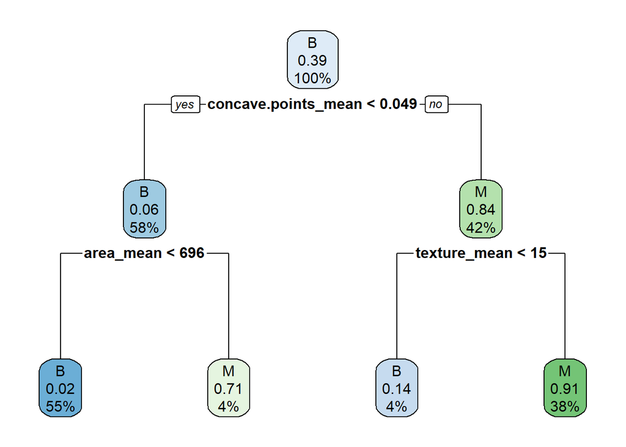

```r
library(rpart)
library(rpart.plot)

breast_tree <- rpart(diagnosis ~ radius_mean + texture_mean + perimeter_mean + area_mean + smoothness_mean + compactness_mean + concavity_mean + concave.points_mean + symmetry_mean + fractal_dimension_mean, data=breast_cancer.train, method = "class")

rpart.plot(breast_tree)
```

- 정확도 판단

```r
# val data acc
pred_test <- predict(breast_tree, breast_cancer.val, type = "class")
acc_test <- sum(pred_test == breast_cancer.val$diagnosis) / nrow(breast_cancer.val)
print(paste("Accuracy: ", acc_test))
```

```
## [1] "Accuracy:  0.923976608187134"
```

- Confusion Matrix(혼동 행렬)

```r
cfm <- confusionMatrix(pred_test, breast_cancer.val$diagnosis)

print(cfm)
```

```
## Confusion Matrix and Statistics
##
##           Reference
## Prediction   B   M
##          B 107   6
##          M   7  51
##
##                Accuracy : 0.924
##                  95% CI : (0.8735, 0.9589)
##     No Information Rate : 0.6667
##     P-Value [Acc > NIR] : 1.21e-15
##
##                   Kappa : 0.8297
##
##  Mcnemar's Test P-Value : 1
##
##             Sensitivity : 0.9386
##             Specificity : 0.8947
##          Pos Pred Value : 0.9469
##          Neg Pred Value : 0.8793
##              Prevalence : 0.6667
##          Detection Rate : 0.6257
##    Detection Prevalence : 0.6608
##       Balanced Accuracy : 0.9167
##
##        'Positive' Class : B
##
```

- ROC 곡선

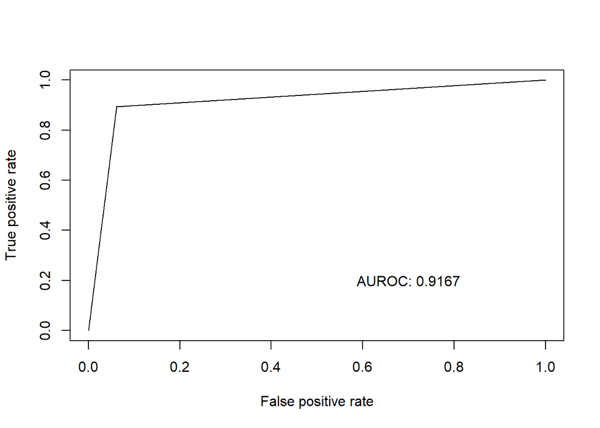

```r
# data 형식 변환
pred_test_numeric <- as.numeric(pred_test)
diagnosis_numeric <- as.numeric(breast_cancer.val$diagnosis)

# ROC curve 생성
pred <- prediction(pred_test_numeric, diagnosis_numeric)
roc <- performance(pred, "tpr", "fpr")

# AUROC 계산
auroc <- performance(pred, measure = "auc")@y.values[[1]]

# ROC curve
plot(roc)

# AUROC 값 그래프에 추가
text(0.7, 0.2, paste("AUROC:", round(auroc, 4)))
```

## RandomForest

```r
library(randomForest)
```

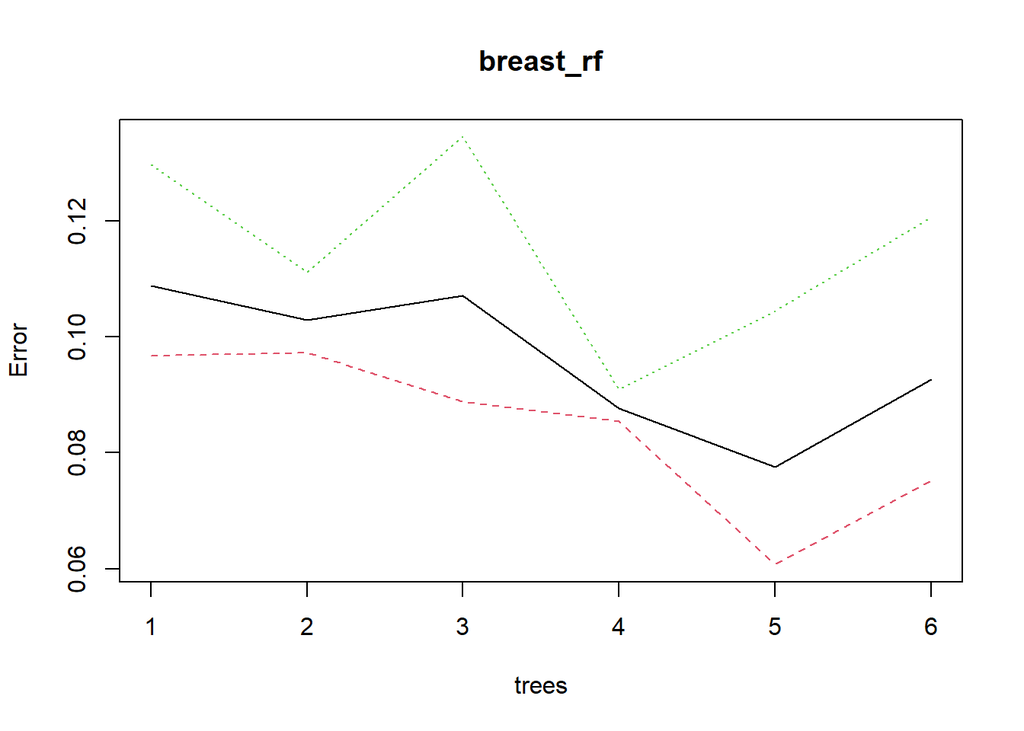

```r
breast_rf <- randomForest(diagnosis ~ radius_mean + texture_mean + perimeter_mean + area_mean + smoothness_mean + compactness_mean + concavity_mean + concave.points_mean + symmetry_mean + fractal_dimension_mean,  data=breast_cancer.train, mtry=3, ntree=6)

plot(breast_rf)
```

- 정확도 판단

```r
pred_test <- predict(breast_rf, breast_cancer.val)
acc_test <- sum(pred_test == breast_cancer.val$diagnosis) / nrow(breast_cancer.val)

print(paste("Accuracy: ", acc_test))
```

```
## [1] "Accuracy:  0.95906432748538"
```

- Confusion Matrix(혼동 행렬)

```r
cfm <- confusionMatrix(pred_test, breast_cancer.val$diagnosis)

print(cfm)
```

```
## Confusion Matrix and Statistics
##
##           Reference
## Prediction   B   M
##          B 111   4
##          M   3  53
##
##                Accuracy : 0.9591
##                  95% CI : (0.9175, 0.9834)
##     No Information Rate : 0.6667
##     P-Value [Acc > NIR] : <2e-16
##
##                   Kappa : 0.9075
##
##  Mcnemar's Test P-Value : 1
##
##             Sensitivity : 0.9737
##             Specificity : 0.9298
##          Pos Pred Value : 0.9652
##          Neg Pred Value : 0.9464
##              Prevalence : 0.6667
##          Detection Rate : 0.6491
##    Detection Prevalence : 0.6725
##       Balanced Accuracy : 0.9518
##
##        'Positive' Class : B
##
```

- ROC 곡선

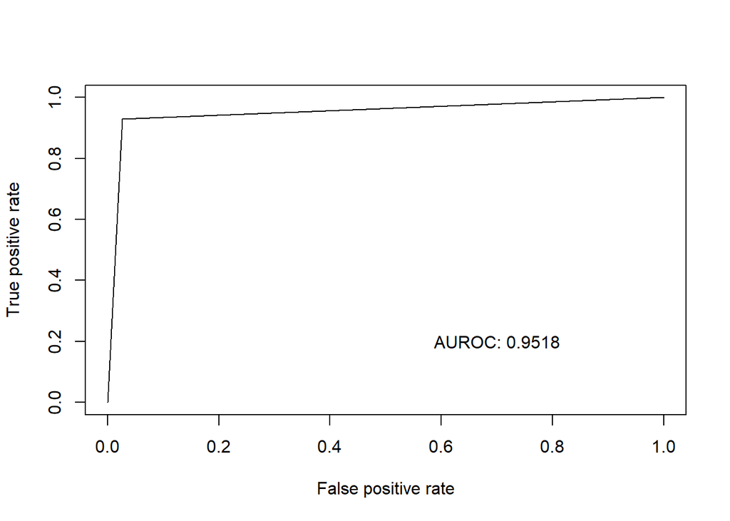

```r
# data 형식 변환
pred_test_numeric <- as.numeric(pred_test)
diagnosis_numeric <- as.numeric(breast_cancer.val$diagnosis)

# ROC curve
pred <- prediction(pred_test_numeric, diagnosis_numeric)
roc <- performance(pred, "tpr", "fpr")

# AUROC 계산
auroc <- performance(pred, measure = "auc")@y.values[[1]]

# ROC curve 그리기
plot(roc)

# AUROC 값 그래프에 추가
text(0.7, 0.2, paste("AUROC:", round(auroc, 4)))
```

## NN

```r
library(nnet)
library(gmodels)

# 학습 데이터에 대한 formula 생성
myform <- as.formula("diagnosis ~ radius_mean + texture_mean + perimeter_mean + area_mean + smoothness_mean + compactness_mean + concavity_mean + concave.points_mean + symmetry_mean + fractal_dimension_mean")

# 모델 학습
breast_nn <- nnet(myform,
                   data = breast_cancer.train,
                   size = 3,
                   rang = 1,
                   decay = 3e-4,
                   maxit = 300)
# val data acc
pred_test <- predict(breast_nn, breast_cancer.val, type = "class")

acc_test <- sum(pred_test == breast_cancer.val$diagnosis)/nrow(breast_cancer.val)
print(paste("Accuracy: ", acc_test))
```

```
## [1] "Accuracy:  0.947368421052632"
```

- Confusion Matrix(혼동 행렬)

```r
# 예측 결과와 실제 레이블을 팩터로 변환
pred_test_factor <- as.factor(pred_test)
actual_labels_factor <- as.factor(breast_cancer.val$diagnosis)

# 팩터의 레벨을 동일하게 설정
levels(pred_test_factor) <- levels(actual_labels_factor)

# Confusion Matrix 생성
confusionMatrix(pred_test_factor, actual_labels_factor)
```

```
## Confusion Matrix and Statistics
##
##           Reference
## Prediction   B   M
##          B 109   4
##          M   5  53
##
##                Accuracy : 0.9474
##                  95% CI : (0.9024, 0.9757)
##     No Information Rate : 0.6667
##     P-Value [Acc > NIR] : <2e-16
##
##                   Kappa : 0.8821
##
##  Mcnemar's Test P-Value : 1
##
##             Sensitivity : 0.9561
##             Specificity : 0.9298
##          Pos Pred Value : 0.9646
##          Neg Pred Value : 0.9138
##              Prevalence : 0.6667
##          Detection Rate : 0.6374
##    Detection Prevalence : 0.6608
##       Balanced Accuracy : 0.9430
##
##        'Positive' Class : B
##
```

- ROC 곡선

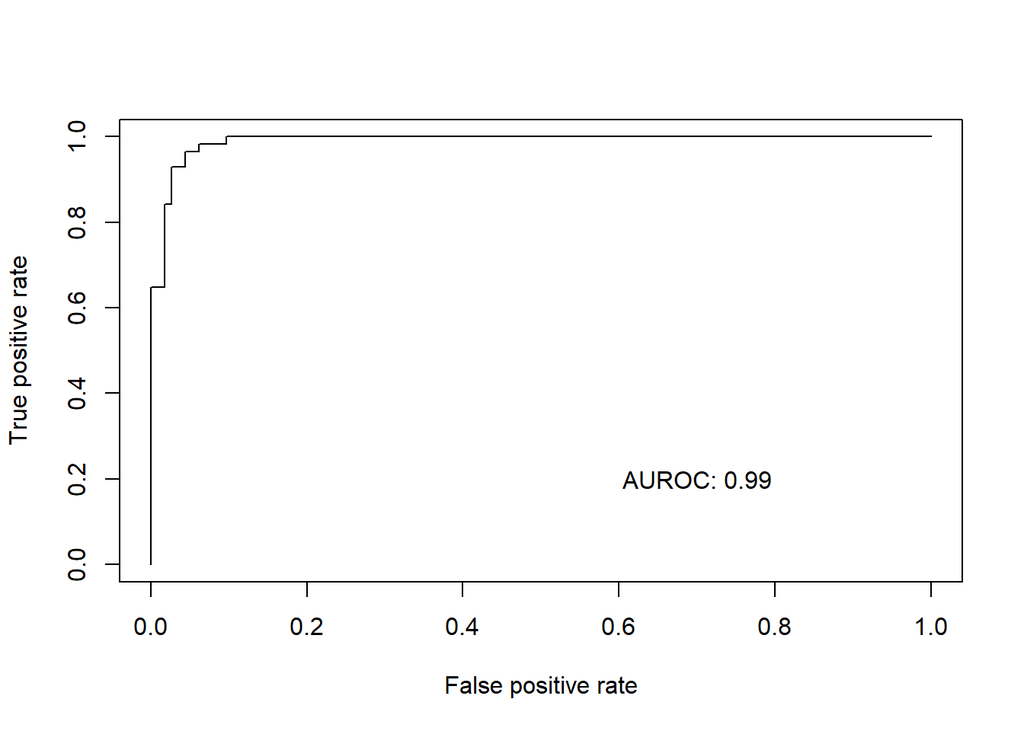

```r
# 예측 확률 계산
predicted_probs <- predict(breast_nn, newdata = breast_cancer.val, type = "raw")

# 실제 값
actual_labels <- as.numeric(breast_cancer.val$diagnosis == "M")

# 예측 결과와 실제 레이블을 이용해 prediction 객체 생성
pred <- prediction(predicted_probs, actual_labels)

# TPR(참 긍정률)과 FPR(거짓 긍정률)을 이용해 performance 객체 생성
perf <- performance(pred, "tpr", "fpr")

# AUROC 계산
auroc <- performance(pred, measure = "auc")@y.values[[1]]

# ROC curve 그리기
plot(perf)

# AUROC 값 그래프에 추가
text(0.7, 0.2, paste("AUROC:", round(auroc, 4)))
```

- seed 값을 현재 고정한 상태인데 위의 NN 모델의 경우 seed 값에 따라 평가지표 수치의 변동이 큼